# Topics in Advanced Statistics

Individual Assignment, April 2017 Eramus University Rotterdam, Econometrics Marnix Koops [432409]

## Introduction

Many statistical methods require complete datasets.Often, this is not the case and observations with missing values are simply removed leading to potential bias. This report will summarise the main findings of a missing data analysis and discuss the results of several imputation techniques followed by regressions.

## Question 1

Implementation of the multiple imputation and nonparametric bootstrap. The code can be found in the accompanied uploaded files on Blackboard.

## Question 2

Next we perform a simulation study to investigate the behavior of OLS and MM-regression after (1) single kNN imputation and (2) multiple iterative model based imputation. The following combinations of situations are investigated:

- Missing data mechanism
  - Missing at Random (MAR) and Missing Not at Random (MNAR)
- Amount of missingness
  - 10%, 25% and 50% missing values
- Outlier types
  - Vertical, good leverage and bad leverage outliers
- Outlier contamination levels
  - 10%, 25% and 50% outliers

In all cases a total of 100 observations are used. To simulate a MNAR mechanism we calculate a probability vector which is consequently used as probability that this observation will be removed from the data. A situation where lower values of $x$ are more likely to be missing than higher values, is achieved by calculating the probabilities as $1/x$. The true data generating process before contamination with outliers and removing observations is described by equation:

> $y$ ~ $\alpha$ $+$ $\beta$ $*$ $x$

where $\alpha$ $=$ $100$, $\beta$ $=$ $2$ and $\sigma$ $=$ $40$

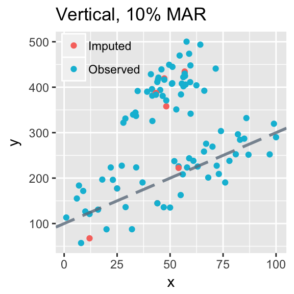

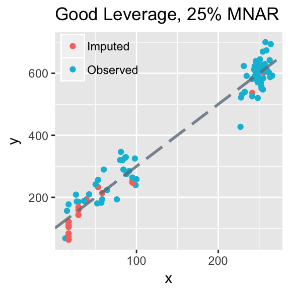

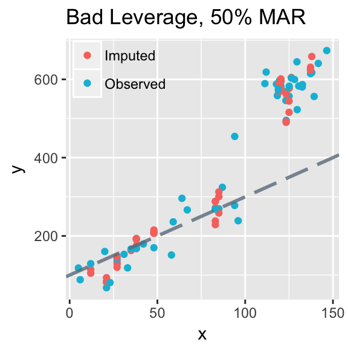

*Figure 1: Examples of scenarios*

> 1: Results after single kNN imputation

|  | $ alpha$ OLS | $ beta$ OLS | $ alpha$ MM | $ beta$_MM |
| --- | --- | --- | --- | --- |
| 10% Outliers | 2.078068 | 3.858873 | 6.155671 | 3.765146 |
| 25% Outliers | -37.344182 | 4.492068 | -37.439216 | 4.522748 |
| 50% Outliers | -52.884557 | 5.027707 | -49.309409 | 5.013794 |

Table 2: Coefficient estimates after kNN imputation [Bad leverage, MCAR]

|  | $ alpha$ OLS | $ beta$ OLS | $ alpha$ MM | $ beta$_MM |
| --- | --- | --- | --- | --- |
| 10% Outliers | 49.797041 | 3.352652 | 52.8186030 | 3.266746 |
| 25% Outliers | -2.615466 | 4.052595 | -2.0662450 | 4.052634 |
| 50% Outliers | 3.249806 | 4.372487 | 0.6164144 | 4.422939 |

## Bonus

In case of multiple datasets we have the luxury to to compare results instead of deciding on a single set. Taking all imputed datasets as reference instead of looking at values within a single imputated dataset leads to less uncertainty. If the same outlying points appears in a large portion of the imputed datasets it is more likely this point is actually an outlier.

## Question 3

To conclude we will analyse the *biopics* dataset by [FiveThirtyEight, 2015]. The data contains information regarding biographical movies scraped from the website IMDb.com. Table 3 displays overview of the variables included and an example observation. The included variables are self-explanatory based on their names. For the factor variables the first level is defined as base-level. A quick analysis reveals that in general most biographical movies feature a white male subject. The reponse variable *box office* is a monetary variable with high values and variation. Thus, we log transform *box office*, this also increases interpretability of the regression estimations.

```
## 'data.frame':    668 obs. of  9 variables:
##  $ title             : chr  "10 Rillington Place" "12 Years a Slave" "127 Hours" "1987" ...
##  $ country           : Factor w/ 4 levels "US","Canada",..: 4 3 3 2 1 1 4 1 1 3 ...
##  $ year_release      : int  1971 2013 2010 2014 1998 2008 2002 2013 1994 1987 ...
##  $ box_office        : num  NA 56700000 18300000 NA 537000 81200000 1130000 95000000 19600000 1080000 ...
##  $ number_of_subjects: int  1 1 1 1 1 1 1 1 1 2 ...
##  $ type_of_subject   : Factor w/ 16 levels "Other","Academic",..: 9 1 6 1 1 1 15 6 6 7 ...
##  $ subject_race      : Factor w/ 7 levels "White","Asian",..: NA 3 NA 1 NA 2 1 3 NA NA ...
##  $ person_of_color   : int  0 1 0 0 0 1 0 1 0 0 ...
##  $ subject_gender    : Factor w/ 3 levels "Male","Female",..: 1 1 1 1 1 1 1 1 1 3 ...
```

Table 3: Overview of Biopics data

| title | country | year_release | box_office | number_of_subjects | type_of_subject | subject_race | person_of_color | subject_gender |
| --- | --- | --- | --- | --- | --- | --- | --- | --- |
| 10 Rillington Place | UK | 1971 | NA | 1 | Criminal | NA | 0 | Male |

### **Missing Data Analysis**

As can be seen in the example in Table 3 not all observations are included and we have to deal with missing data. We start by looking at the missing data and the pattern. Table 4 shows a summary of the missingness. Approximately 40% of the movies have no missing information and there are no cases where there are more than 2 variables missing. 60% of the movies have at least one missing value.

Table 4: Summary of missing data

| # of Missing by Case | # of Cases | Percentage |
| --- | --- | --- |
| 0 | 270 | 40.4 |
| 1 | 328 | 49.1 |
| 2 | 70 | 10.5 |

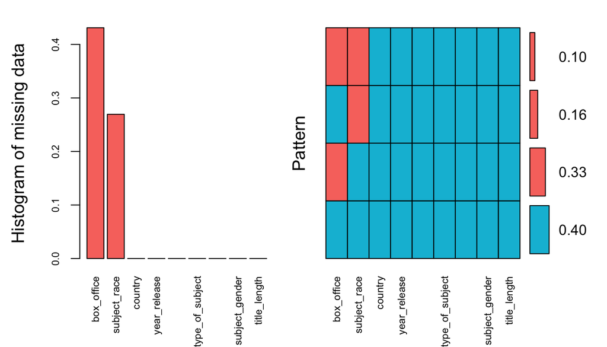

*Figure 2: Missing data and pattern in Biopics*

Figure 2 reveals that only *box office* is missing in roughly 33% and only *subject race* is missing in 16% of the observations. These variables are missing together in the same observation for 10% of the movies. This amounts to a total of 60% as stated.

There are three distinct cases of missing data: MCAR, MAR, MNAR [Little & Rubin, 2002]. MNAR is most problematic for further analysis but in all cases information is lost by omitting incomplete observations. Estimating the missing values, imputation, will likely yield more reliable results.

In assumption of random missingness the boxplots in Figure 3 should be similar, we see that this is not the case. In these examples the marginplot reveals that *subject race* is missing more often in newer movies. It also shows that there are many biographical movies with a white *subject race* (corresponding to the value 0.2 on the x-axis). On contrary, *box office* is missing more often in older movies. Furthermore, we see that higher *box office* amounts occur more frequently in newer released movies. In short; the missing data mechanism does not appear to be random in the *biopocics* data.

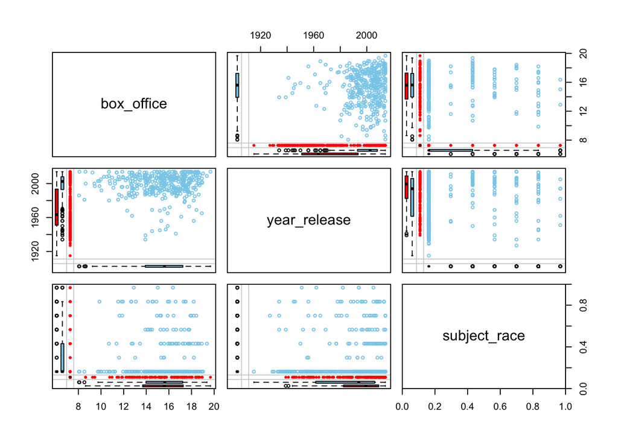

*Figure 3: Margin plot of Biopics data*

Figure 3 displays some outlying observations with a very high *box office* compared to the general expected pattern; two in the top right around 2010 and one around 1965. The movies belonging to these observations are shown in Table 5, they are all produced in the same *country*, US, but cover a different *subject*.

Table 5: High grossing movies

|  | title | country | year_release | box_office | number_of_subjects | type_of_subject | subject_race | person_of_color | subject_gender |
| --- | --- | --- | --- | --- | --- | --- | --- | --- | --- |
| 33 | American Sniper | US | 2014 | 3.50e+08 | 1 | Military | NA | 0 | Male |
| 475 | The Blind Side | US | 2009 | 2.56e+08 | 1 | Athlete | Black | 1 | Male |
| 590 | The Sound of Music | US | 1965 | 1.63e+08 | 1 | Musician/Singer | White | 0 | Female |

### **Imputation**

Next, we investigate regressions using *box office* as response variable in three cases: (1) after simply excluding incomplete cases, (2) after kNN imputation with bootstrapped standard errors and (3) after multiple iterative model-based imputation. Since a large portion of our observations contain missing values we expect approach (1) to give biased results and approach (2) and (3) to be more reliable and yield more comparable results.

We found *title* is not missing in any of the cases and is unique for every movie. However, this variable may provide information and disregarding this in the regression does not seem smart. Therefore, an extra numeric variable is added to the analysis that represents the length of the title. It is a possibility there exists a relation between *box office* and the length of the title of the movie.

## 1: Ignoring incomplete cases

First, an easy solution and common approach is taken by simply removing observations containing missing values. This leads to ignoring information regarding 60% of the movies in our data. The result are likely biased since we have found our missing values are MNAR.

### Interpretation of Results

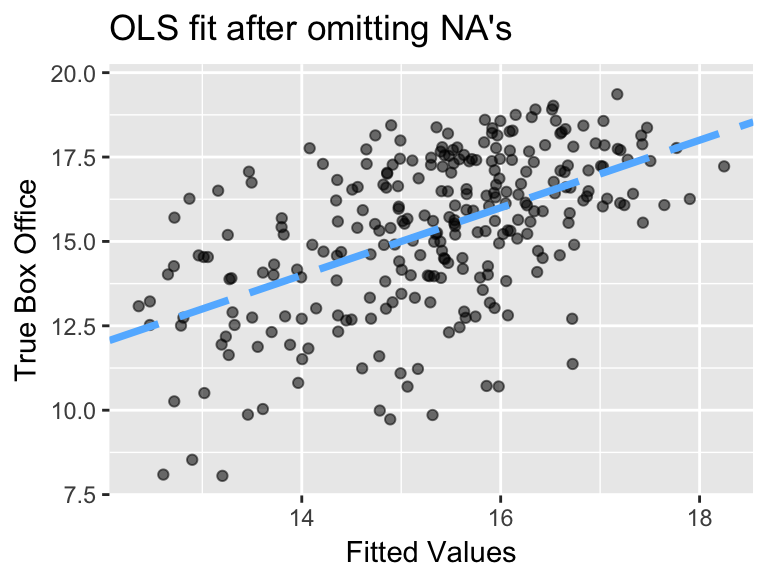

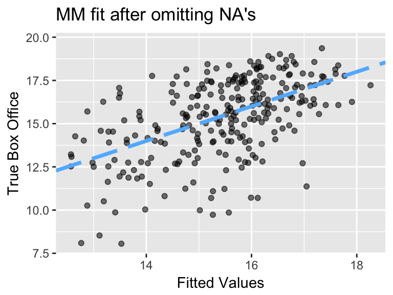

*Figure 4: OLS and MM fit after omitting NA’s*

Including the full variable selection in the regression yields differing results for OLS and MM. In the OLS regression the following variables are significant:

- *Country (Canada)*: Negative effect on *box office*
- *Country (UK)*: Negative effect on *box office*
- *Subject Type (Actor/Actress)*: Negative effect on *box office*
- *Subject Gender (Female)*: Positive effect on *box office*

In the MM regression the following variables are significant:

- *Country (Canada)*: Negative effect on *box office*
- *Country (UK)*: Negative effect on *box office*
- *Subject Type (Actor/Actress)*: Negative effect on *box office*
- *Subject Type (Author)*: Negative effect on *box office*

In order to compare goodness of fit we calculate accuracy metrics for the two regressions. Since we have presence of outliers the MSPE is not the best choice, as this metric is highly influenced by outliers. The MAPE is also not optimal due to giving equal weights to all observations. A better option is the MAD, as the median is a robust measure of univariate location which is the case for residuals. MM provides a better fit than OLS based on the MAD.

| MAD of OLS regression | MAD of MM regression |
| --- | --- |
| 1.381085 | 1.337685 |

### Estimation Results of OLS

Table 6: Estimation Results of ignoring NA’s and OLS regression

|  | Estimate | Std. Error | t value | Pr(>\|t\|) |
| --- | --- | --- | --- | --- |
| (Intercept) | 11.7636388 | 20.5488744 | 0.5724712 | 0.5675409 |
| countryCanada | -2.4483605 | 0.9835232 | -2.4893775 | 0.0134780 |
| countryMulti country | -0.2781129 | 0.3489676 | -0.7969590 | 0.4262658 |
| countryUK | -1.6716516 | 0.3903271 | -4.2826945 | 0.0000268 |
| year_release | 0.0019338 | 0.0102665 | 0.1883618 | 0.8507529 |
| number_of_subjects | 0.1260105 | 0.4552185 | 0.2768132 | 0.7821628 |
| type_of_subjectAcademic | 1.5821519 | 0.9820109 | 1.6111347 | 0.1084702 |
| type_of_subjectActivist | -0.7614845 | 0.5609531 | -1.3574834 | 0.1759081 |
| type_of_subjectActor/Actress | -2.4624321 | 0.6734879 | -3.6562382 | 0.0003147 |
| type_of_subjectArtist | -0.6137029 | 0.6347842 | -0.9667898 | 0.3346264 |
| type_of_subjectAthlete | 0.4068405 | 0.5241545 | 0.7761844 | 0.4384075 |
| type_of_subjectAuthor | -0.9947835 | 0.5437906 | -1.8293504 | 0.0685930 |
| type_of_subjectComedian | -0.0304388 | 1.0882235 | -0.0279711 | 0.9777085 |
| type_of_subjectCriminal | -0.0983991 | 0.5618282 | -0.1751409 | 0.8611172 |
| type_of_subjectHistorical | 1.0651368 | 0.5810742 | 1.8330476 | 0.0680394 |
| type_of_subjectMedia | 0.0444344 | 1.0935324 | 0.0406338 | 0.9676217 |
| type_of_subjectMedicine | 2.2736664 | 2.0876026 | 1.0891280 | 0.2771944 |
| type_of_subjectMilitary | -0.7651184 | 0.7944674 | -0.9630584 | 0.3364916 |
| type_of_subjectMulti type | 0.8393212 | 0.8599265 | 0.9760382 | 0.3300324 |
| type_of_subjectMusician/Singer | 0.3902930 | 0.4668347 | 0.8360412 | 0.4039668 |
| type_of_subjectPolitician/Leader | 0.9186425 | 0.8037651 | 1.1429241 | 0.2542137 |
| subject_raceAsian | 0.1628692 | 1.1105738 | 0.1466532 | 0.8835294 |
| subject_raceBlack | 1.3052532 | 0.8345264 | 1.5640646 | 0.1191255 |
| subject_raceHispanic | 0.7766025 | 0.7611209 | 1.0203405 | 0.3085987 |
| subject_raceMiddle Eastern | 0.3484419 | 0.7926671 | 0.4395816 | 0.6606373 |
| subject_raceMulti racial | -0.8612279 | 0.7660934 | -1.1241813 | 0.2620640 |
| subject_raceOther | -1.1128953 | 1.4907718 | -0.7465229 | 0.4560853 |
| person_of_color | 0.0256737 | 0.7341455 | 0.0349708 | 0.9721322 |
| subject_genderFemale | 0.7068582 | 0.3331507 | 2.1217373 | 0.0348892 |
| subject_genderMulti gender | 0.5326364 | 0.7942844 | 0.6705865 | 0.5031315 |
| title_length | -0.0242926 | 0.0171800 | -1.4140093 | 0.1586605 |

### Estimation Results of MM

Table 7: Estimation Results of ignoring NA’s and MM regression

|  | Estimate | Std. Error | t value | Pr(>\|t\|) |
| --- | --- | --- | --- | --- |
| (Intercept) | 12.0478802 | 20.4098305 | 0.5902979 | 0.5555487 |
| countryCanada | -2.6226805 | 0.9660315 | -2.7149016 | 0.0071131 |
| countryMulti country | -0.2506891 | 0.3471278 | -0.7221810 | 0.4708892 |
| countryUK | -1.5159059 | 0.3923447 | -3.8637093 | 0.0001439 |
| year_release | 0.0019098 | 0.0101994 | 0.1872432 | 0.8516288 |
| number_of_subjects | 0.1218298 | 0.4526984 | 0.2691191 | 0.7880702 |
| type_of_subjectAcademic | 1.3461763 | 0.9638914 | 1.3966057 | 0.1638277 |
| type_of_subjectActivist | -0.8449620 | 0.5581354 | -1.5139015 | 0.1313721 |
| type_of_subjectActor/Actress | -2.4594567 | 0.6704594 | -3.6683158 | 0.0003010 |
| type_of_subjectArtist | -0.6682020 | 0.6355431 | -1.0513874 | 0.2941426 |
| type_of_subjectAthlete | 0.3163522 | 0.5212633 | 0.6068952 | 0.5444966 |
| type_of_subjectAuthor | -1.2074577 | 0.5428351 | -2.2243546 | 0.0270594 |
| type_of_subjectComedian | -0.2541230 | 1.0675629 | -0.2380403 | 0.8120538 |
| type_of_subjectCriminal | -0.0322394 | 0.5684104 | -0.0567186 | 0.9548168 |
| type_of_subjectHistorical | 1.0631718 | 0.5805172 | 1.8314219 | 0.0682823 |
| type_of_subjectMedia | -0.0845576 | 1.0724933 | -0.0788420 | 0.9372242 |
| type_of_subjectMedicine | 2.0505815 | 2.0444051 | 1.0030211 | 0.3168651 |
| type_of_subjectMilitary | -0.9689911 | 0.7959611 | -1.2173850 | 0.2246584 |
| type_of_subjectMulti type | 0.6585359 | 0.8466242 | 0.7778374 | 0.4374342 |
| type_of_subjectMusician/Singer | 0.3036265 | 0.4657486 | 0.6519109 | 0.5150851 |
| type_of_subjectPolitician/Leader | 0.7034894 | 0.7950673 | 0.8848174 | 0.3771444 |
| subject_raceAsian | 0.1346832 | 1.0985513 | 0.1226007 | 0.9025263 |
| subject_raceBlack | 1.3558415 | 0.8274834 | 1.6385121 | 0.1026307 |
| subject_raceHispanic | 0.6334836 | 0.7532968 | 0.8409481 | 0.4012175 |
| subject_raceMiddle Eastern | 0.1469178 | 0.7832671 | 0.1875704 | 0.8513725 |
| subject_raceMulti racial | -0.9512910 | 0.7610024 | -1.2500500 | 0.2125039 |
| subject_raceOther | -1.2909313 | 1.4681316 | -0.8793022 | 0.3801207 |
| person_of_color | 0.0107895 | 0.7271507 | 0.0148381 | 0.9881737 |
| subject_genderFemale | 0.5483129 | 0.3311865 | 1.6556016 | 0.0991149 |
| subject_genderMulti gender | 0.3866566 | 0.7856427 | 0.4921532 | 0.6230628 |
| title_length | -0.0252051 | 0.0171207 | -1.4722037 | 0.1422815 |

## 2: kNN imputation with bootstrapped standard errors

Next, we draw bootstrap samples of the *biopics* data with replacement and use kNN on each sample to impute the missing values. Consequently, we apply OLS and MM regressions on the complete imputed datasets. Tables of the pooled regression results are found in the second and third tab below. The first tab is an interpretation of these results.

### Interpretation of Results

In the OLS regression the following variables are significant:

- *Country (Canada)*: Negative effect on *box office*
- *Country (UK)*: Negative effect on *box office*
- *Subject Type (Actor/Actress)*: Negative effect on *box office*
- *Subject Type (Author)*: Negative effect on *box office*

And the following variables are just above the cut-off value of significance with a p-value of roughly 0.08: * *Subject Race (Black)*: Positive effect on *box office* * *Subject Gender (Female)*: Positive effect on *box office*

### Pooled Estimation Results of OLS

Table 8: Results of OLS regression after kNN imputation on bootstrapped samples

|  | pooled_est | std_error | z_val | p_val |
| --- | --- | --- | --- | --- |
| (Intercept) | 10.6071396 | 7.3573925 | 1.4416982 | 0.1498805 |
| countryCanada | -1.3251486 | 0.5627734 | -2.3546755 | 0.0188423 |
| countryMulti country | -0.1468975 | 0.2542908 | -0.5776752 | 0.5636882 |
| countryUK | -0.9821676 | 0.2244535 | -4.3758169 | 0.0000141 |
| year_release | 0.0023895 | 0.0036961 | 0.6465039 | 0.5181866 |
| number_of_subjects | 0.2248932 | 0.2651043 | 0.8483197 | 0.3965796 |
| type_of_subjectAcademic | 0.6062876 | 0.5349958 | 1.1332567 | 0.2575342 |
| type_of_subjectActivist | -0.2681802 | 0.4297711 | -0.6240071 | 0.5328470 |
| type_of_subjectActor/Actress | -1.1882862 | 0.4151342 | -2.8624143 | 0.0043428 |
| type_of_subjectArtist | -0.6363775 | 0.4559777 | -1.3956330 | 0.1633129 |
| type_of_subjectAthlete | 0.1951512 | 0.3068446 | 0.6359936 | 0.5250098 |
| type_of_subjectAuthor | -0.9104310 | 0.3745193 | -2.4309323 | 0.0153358 |
| type_of_subjectComedian | -0.0132008 | 0.8157757 | -0.0161819 | 0.9870943 |
| type_of_subjectCriminal | -0.3723609 | 0.3073278 | -1.2116082 | 0.2261130 |
| type_of_subjectHistorical | 0.1894407 | 0.3323965 | 0.5699238 | 0.5689310 |
| type_of_subjectMedia | 0.1189478 | 0.7087402 | 0.1678300 | 0.8667705 |
| type_of_subjectMedicine | 0.8361446 | 0.7353700 | 1.1370392 | 0.2559508 |
| type_of_subjectMilitary | 0.1375638 | 0.3620447 | 0.3799636 | 0.7040995 |
| type_of_subjectMulti type | 0.1299413 | 0.5487194 | 0.2368083 | 0.8128819 |
| type_of_subjectMusician/Singer | -0.0562352 | 0.2880549 | -0.1952237 | 0.8452803 |
| type_of_subjectPolitician/Leader | 0.4920989 | 0.5554219 | 0.8859912 | 0.3759577 |
| subject_raceAsian | 0.1471047 | 0.8933177 | 0.1646723 | 0.8692543 |
| subject_raceBlack | 1.0901739 | 0.6125529 | 1.7797221 | 0.0755996 |
| subject_raceHispanic | 0.1294298 | 0.6136925 | 0.2109033 | 0.8330304 |
| subject_raceMiddle Eastern | 0.4706553 | 0.5323113 | 0.8841731 | 0.3769374 |
| subject_raceMulti racial | -0.4624815 | 0.5322273 | -0.8689549 | 0.3852001 |
| subject_raceOther | -0.0894015 | 1.0355505 | -0.0863323 | 0.9312295 |
| person_of_color | -0.1064926 | 0.5158554 | -0.2064389 | 0.8365142 |
| subject_genderFemale | 0.3797686 | 0.2097013 | 1.8109978 | 0.0706136 |
| subject_genderMulti gender | -0.2595540 | 0.4628347 | -0.5607919 | 0.5751372 |
| title_length | -0.0031491 | 0.0104443 | -0.3015174 | 0.7631187 |

### Pooled Estimation Results of MM

Table 9: Results of MM regression after kNN imputation on bootstrapped samples

|  | pooled_est | std_error | z_val | p_val |
| --- | --- | --- | --- | --- |
| (Intercept) | 6.3510685 | NA | NA | NA |
| countryCanada | -1.7201825 | NA | NA | NA |
| countryMulti country | -0.0436094 | NA | NA | NA |
| countryUK | -1.0113258 | NA | NA | NA |
| year_release | 0.0048161 | NA | NA | NA |
| number_of_subjects | 0.0657977 | NA | NA | NA |
| type_of_subjectAcademic | 0.4675431 | NA | NA | NA |
| type_of_subjectActivist | -0.1294167 | NA | NA | NA |
| type_of_subjectActor/Actress | -1.3631928 | NA | NA | NA |
| type_of_subjectArtist | -0.6797503 | NA | NA | NA |
| type_of_subjectAthlete | 0.1872355 | NA | NA | NA |
| type_of_subjectAuthor | -0.9712884 | NA | NA | NA |
| type_of_subjectComedian | -0.2776877 | NA | NA | NA |
| type_of_subjectCriminal | -0.2958058 | NA | NA | NA |
| type_of_subjectHistorical | 0.1033480 | NA | NA | NA |
| type_of_subjectMedia | -0.2302161 | NA | NA | NA |
| type_of_subjectMedicine | 0.5243045 | NA | NA | NA |
| type_of_subjectMilitary | 0.2351613 | NA | NA | NA |
| type_of_subjectMulti type | 0.0986682 | NA | NA | NA |
| type_of_subjectMusician/Singer | -0.0418306 | NA | NA | NA |
| type_of_subjectPolitician/Leader | 0.3055566 | NA | NA | NA |
| subject_raceAsian | -0.1607806 | NA | NA | NA |
| subject_raceBlack | 0.8917809 | NA | NA | NA |
| subject_raceHispanic | -0.3940893 | NA | NA | NA |
| subject_raceMiddle Eastern | 0.3652199 | NA | NA | NA |
| subject_raceMulti racial | -0.6327090 | NA | NA | NA |
| subject_raceOther | -0.4131638 | NA | NA | NA |
| person_of_color | -0.0191273 | NA | NA | NA |
| subject_genderFemale | 0.1886472 | NA | NA | NA |
| subject_genderMulti gender | -0.2918744 | NA | NA | NA |
| title_length | -0.0077279 | NA | NA | NA |

## 3: Multiple iterative model-based imputation

The main advantage of this method is that valid inference can be performed in case of missing values. In theory multiple imputation can work for all three types of missing data but MNAR is more complicated. The uncertainty induced between the multiple imputed datasets reflect the uncertainty caused by the missing values [van Buuren, 1999]. The amount of imputations $m$ is set approximately equal to the percentage of incomplete observations as suggested by [Bodner, 2008] and [White et al. 2011]. For the *biopics* data we use $m=60$ imputations. To impute the numerical values for *box office* predictive mean matching (pmm) is used. For *subject race* Bayesian polytomous regression (polyreg) is used, which is the default for unordered factors with more than two levels.

Before we interpret the results it is interesting to inspect the imputations we have done. It is of importance that the imputation yields reliable values compared to the values that are observed.

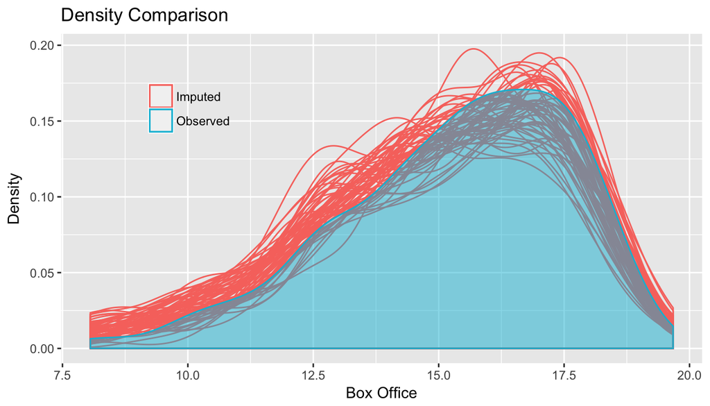

*Figure 5: Density Comparison*

Figure 5 compares the densities of *box office* in the imputed dataset with the density of *box office* in the originally observed data. Some deviation is to be expected from imputing the data 60 times and may actually be of use. This will incorporate uncertainty from the missing values into our analysis. The imputed values seem to be a bit higher on average than the observed values for lower *box office* values. However, the central tendency and overall shape of the densities appear to be comparable.

### Interpretation of Results

Including the full variable selection in the regression yields differing results for OLS and MM. In the OLS regression the following variables are significant:

- *Country 2 (Canada)*: Negative effect on *box office*
- *Country 4 (UK)*: Negative effect on *box office*
- *Subject Type 4 (Actor/Actress)*: Negative effect on *box office*
- *Subject Type 7 (Author)*: Negative effect on *box office*
- *Subject Gender (Female)*: Positive effect on *box office*

For the MM regression the following variables are significant:

- *Country 2 (Canada)*: Negative effect on *box office*
- *Country 4 (UK)*: Negative effect on *box office*
- *Subject Type 4 (Actor/Actress)*: Negative effect on *box office*
- *Subject Type 7 (Author)*: Negative effect on *box office*

### Pooled Estimation Results of OLS

Table 10: Pooled multiple imputation results after OLS regression

|  | est | se | t | df | Pr(>\|t\|) | lo 95 | hi 95 | nmis | fmi | lambda |
| --- | --- | --- | --- | --- | --- | --- | --- | --- | --- | --- |
| (Intercept) | 2.7678663 | 14.0369104 | 0.1971849 | 73.27735 | 0.8442288 | -25.2058721 | 30.7416046 | NA | 0.7100403 | 0.7022329 |
| country2 | -2.2983840 | 0.8352138 | -2.7518512 | 122.85484 | 0.0068238 | -3.9516578 | -0.6451101 | NA | 0.5385683 | 0.5311171 |
| country3 | -0.2526083 | 0.2880719 | -0.8768931 | 452.66626 | 0.3810098 | -0.8187324 | 0.3135159 | NA | 0.1502854 | 0.1465395 |
| country4 | -2.0247492 | 0.3087014 | -6.5589245 | 178.75978 | 0.0000000 | -2.6339170 | -1.4155815 | NA | 0.4205407 | 0.4140937 |
| year_release | 0.0061991 | 0.0070337 | 0.8813391 | 73.65536 | 0.3810013 | -0.0078170 | 0.0202151 | 0 | 0.7083557 | 0.7005426 |
| number_of_subjects | 0.4400467 | 0.3503454 | 1.2560370 | 183.39746 | 0.2107003 | -0.2511789 | 1.1312723 | 0 | 0.4127892 | 0.4064202 |
| type_of_subject2 | 0.7563987 | 0.7473502 | 1.0121075 | 157.28393 | 0.3130411 | -0.7197385 | 2.2325360 | NA | 0.4598671 | 0.4530422 |
| type_of_subject3 | -0.2874788 | 0.5320550 | -0.5403178 | 292.28522 | 0.5893894 | -1.3346233 | 0.7596658 | NA | 0.2772720 | 0.2723435 |
| type_of_subject4 | -1.9270578 | 0.6149608 | -3.1336270 | 136.60899 | 0.0021134 | -3.1431315 | -0.7109841 | NA | 0.5043252 | 0.4971211 |
| type_of_subject5 | -0.4601152 | 0.5879043 | -0.7826363 | 222.62283 | 0.4346724 | -1.6186848 | 0.6984543 | NA | 0.3553097 | 0.3495439 |
| type_of_subject6 | 0.4483994 | 0.4034870 | 1.1113108 | 218.19057 | 0.2676577 | -0.3468314 | 1.2436303 | NA | 0.3611835 | 0.3553547 |
| type_of_subject7 | -0.9254880 | 0.4579458 | -2.0209553 | 303.02340 | 0.0441635 | -1.8266444 | -0.0243315 | NA | 0.2670568 | 0.2622351 |
| type_of_subject8 | 0.0898387 | 0.9023668 | 0.0995590 | 437.06682 | 0.9207401 | -1.6836789 | 1.8633564 | NA | 0.1611128 | 0.1572828 |
| type_of_subject9 | -0.0650678 | 0.4164207 | -0.1562551 | 192.17123 | 0.8759960 | -0.8864100 | 0.7562743 | NA | 0.3987444 | 0.3925193 |
| type_of_subject10 | 0.8619114 | 0.5408844 | 1.5935224 | 107.95659 | 0.1139668 | -0.2102202 | 1.9340429 | NA | 0.5810491 | 0.5733589 |
| type_of_subject11 | 0.3516110 | 0.9884108 | 0.3557337 | 140.04975 | 0.7225753 | -1.6025243 | 2.3057463 | NA | 0.4963912 | 0.4892503 |
| type_of_subject12 | 1.3336153 | 0.9451520 | 1.4110062 | 192.10483 | 0.1598602 | -0.5305927 | 3.1978233 | NA | 0.3988478 | 0.3926217 |
| type_of_subject13 | 0.5723066 | 0.6446604 | 0.8877644 | 84.94130 | 0.3771744 | -0.7094638 | 1.8540770 | NA | 0.6610940 | 0.6532071 |
| type_of_subject14 | 0.6562270 | 0.7256684 | 0.9043069 | 190.20566 | 0.3669766 | -0.7751645 | 2.0876186 | NA | 0.4018236 | 0.3955667 |
| type_of_subject15 | 0.1301148 | 0.3915245 | 0.3323286 | 189.50828 | 0.7400085 | -0.6421912 | 0.9024208 | NA | 0.4029252 | 0.3966569 |
| type_of_subject16 | 1.1353498 | 0.7426333 | 1.5288162 | 181.09863 | 0.1280548 | -0.3299769 | 2.6006766 | NA | 0.4166019 | 0.4101944 |
| subject_race2 | -0.0103025 | 1.1086620 | -0.0092928 | 171.96717 | 0.9925963 | -2.1986403 | 2.1780353 | NA | 0.4323390 | 0.4257752 |
| subject_race3 | 1.1912330 | 0.8168154 | 1.4583870 | 174.42519 | 0.1465322 | -0.4208811 | 2.8033472 | NA | 0.4280062 | 0.4214850 |
| subject_race4 | 0.7389654 | 0.7251475 | 1.0190552 | 204.55013 | 0.3093805 | -0.6907567 | 2.1686874 | NA | 0.3801731 | 0.3741422 |
| subject_race5 | 0.3188913 | 0.7492891 | 0.4255918 | 167.28352 | 0.6709523 | -1.1603901 | 1.7981727 | NA | 0.4408040 | 0.4341581 |
| subject_race6 | -1.0738013 | 0.8500599 | -1.2632067 | 88.86834 | 0.2098190 | -2.7628867 | 0.6152840 | NA | 0.6459776 | 0.6380989 |
| subject_race7 | -0.6396305 | 1.3758738 | -0.4648904 | 145.01404 | 0.6427072 | -3.3589872 | 2.0797261 | NA | 0.4853429 | 0.4782935 |
| person_of_color | 0.0803689 | 0.7175379 | 0.1120064 | 137.02884 | 0.9109822 | -1.3385103 | 1.4992480 | 0 | 0.5033445 | 0.4961481 |
| subject_gender2 | 0.6523177 | 0.2825884 | 2.3083672 | 194.38847 | 0.0220307 | 0.0949848 | 1.2096506 | NA | 0.3953156 | 0.3891261 |
| subject_gender3 | 0.1331223 | 0.6209591 | 0.2143817 | 187.92796 | 0.8304818 | -1.0918237 | 1.3580683 | NA | 0.4054394 | 0.3991453 |
| title_length | -0.0141618 | 0.0142791 | -0.9917837 | 174.16378 | 0.3226790 | -0.0423443 | 0.0140206 | 0 | 0.4284635 | 0.4219378 |

### Pooled Estimation Results of MM

Table 11: Pooled multiple imputation results after robust MM regression

|  | est | se | t | df | Pr(>\|t\|) | lo 95 | hi 95 | nmis | fmi | lambda |
| --- | --- | --- | --- | --- | --- | --- | --- | --- | --- | --- |
| (Intercept) | 2.7618591 | 13.5140828 | 0.2043690 | 77.05075 | 0.8386040 | -24.1478347 | 29.6715529 | NA | 0.6935225 | 0.6856693 |
| country2 | -2.4056753 | 0.8099330 | -2.9702152 | 127.48696 | 0.0035571 | -4.0083277 | -0.8030229 | NA | 0.5265551 | 0.5191855 |
| country3 | -0.1613210 | 0.2879319 | -0.5602749 | 437.18680 | 0.5755789 | -0.7272238 | 0.4045817 | NA | 0.1610289 | 0.1571997 |
| country4 | -2.0623344 | 0.3112262 | -6.6264798 | 167.02806 | 0.0000000 | -2.6767786 | -1.4478902 | NA | 0.4412738 | 0.4346234 |
| year_release | 0.0063246 | 0.0067601 | 0.9355757 | 77.73229 | 0.3523892 | -0.0071344 | 0.0197835 | 0 | 0.6906097 | 0.6827504 |
| number_of_subjects | 0.4074616 | 0.3371541 | 1.2085323 | 201.71117 | 0.2282574 | -0.2573369 | 1.0722601 | 0 | 0.3843126 | 0.3782380 |
| type_of_subject2 | 0.7137446 | 0.7549383 | 0.9454344 | 148.27694 | 0.3459752 | -0.7780829 | 2.2055721 | NA | 0.4783236 | 0.4713342 |
| type_of_subject3 | -0.3192430 | 0.5132067 | -0.6220554 | 326.07423 | 0.5343402 | -1.3288570 | 0.6903710 | NA | 0.2463006 | 0.2416919 |
| type_of_subject4 | -1.9138631 | 0.6216024 | -3.0789182 | 128.84719 | 0.0025394 | -3.1437326 | -0.6839936 | NA | 0.5231238 | 0.5157786 |
| type_of_subject5 | -0.5011116 | 0.5919710 | -0.8465137 | 209.84512 | 0.3982305 | -1.6680838 | 0.6658606 | NA | 0.3726302 | 0.3666792 |
| type_of_subject6 | 0.4151877 | 0.3952978 | 1.0503163 | 225.11842 | 0.2946989 | -0.3637694 | 1.1941449 | NA | 0.3520618 | 0.3463309 |
| type_of_subject7 | -1.0408242 | 0.4662893 | -2.2321425 | 266.15086 | 0.0264379 | -1.9589094 | -0.1227391 | NA | 0.3038755 | 0.2986640 |
| type_of_subject8 | -0.0978136 | 0.8660032 | -0.1129484 | 470.85858 | 0.9101196 | -1.7995229 | 1.6038956 | NA | 0.1378032 | 0.1341487 |
| type_of_subject9 | 0.0546379 | 0.4185471 | 0.1305419 | 187.16540 | 0.8962779 | -0.7710381 | 0.8803139 | NA | 0.4066616 | 0.4003550 |
| type_of_subject10 | 0.7967810 | 0.5228557 | 1.5239024 | 113.27132 | 0.1303202 | -0.2390635 | 1.8326255 | NA | 0.5651711 | 0.5575606 |
| type_of_subject11 | 0.2323433 | 0.9648371 | 0.2408109 | 143.14466 | 0.8100462 | -1.6748263 | 2.1395129 | NA | 0.4894498 | 0.4823659 |
| type_of_subject12 | 1.1759112 | 0.9034876 | 1.3015244 | 208.65668 | 0.1945142 | -0.6052229 | 2.9570452 | NA | 0.3743036 | 0.3683348 |
| type_of_subject13 | 0.5555283 | 0.6591030 | 0.8428550 | 80.10605 | 0.4018192 | -0.7561018 | 1.8671583 | NA | 0.6806315 | 0.6727561 |
| type_of_subject14 | 0.6980497 | 0.6860209 | 1.0175343 | 224.17752 | 0.3099962 | -0.6538247 | 2.0499242 | NA | 0.3532815 | 0.3475374 |
| type_of_subject15 | 0.1002848 | 0.3878593 | 0.2585598 | 189.94818 | 0.7962549 | -0.6647800 | 0.8653496 | NA | 0.4022297 | 0.3959687 |
| type_of_subject16 | 1.0307255 | 0.7016367 | 1.4690302 | 209.43144 | 0.1433251 | -0.3524501 | 2.4139010 | NA | 0.3732114 | 0.3672543 |
| subject_race2 | 0.0669668 | 1.0927981 | 0.0612802 | 169.61343 | 0.9512082 | -2.0902701 | 2.2242038 | NA | 0.4365580 | 0.4299531 |
| subject_race3 | 1.3204612 | 0.8099866 | 1.6302259 | 170.95298 | 0.1048949 | -0.2784021 | 2.9193244 | NA | 0.4341484 | 0.4275669 |
| subject_race4 | 0.6831844 | 0.7175868 | 0.9520583 | 197.36152 | 0.3422319 | -0.7319374 | 2.0983062 | NA | 0.3907901 | 0.3846477 |
| subject_race5 | 0.2935397 | 0.7243807 | 0.4052285 | 177.41542 | 0.6857978 | -1.1359716 | 1.7230510 | NA | 0.4228328 | 0.4163628 |
| subject_race6 | -1.0055446 | 0.8743637 | -1.1500302 | 83.49871 | 0.2534146 | -2.7444652 | 0.7333759 | NA | 0.6668141 | 0.6589280 |
| subject_race7 | -0.6126093 | 1.3302679 | -0.4605157 | 151.40067 | 0.6458069 | -3.2408950 | 2.0156765 | NA | 0.4717743 | 0.4648422 |
| person_of_color | -0.0542077 | 0.7207500 | -0.0752101 | 129.65530 | 0.9401634 | -1.4801609 | 1.3717455 | 0 | 0.5211053 | 0.5137746 |
| subject_gender2 | 0.5314532 | 0.2734128 | 1.9437759 | 208.80550 | 0.0532663 | -0.0075501 | 1.0704566 | NA | 0.3740934 | 0.3681269 |
| subject_gender3 | 0.0795237 | 0.5912168 | 0.1345085 | 215.97377 | 0.8931257 | -1.0857699 | 1.2448173 | NA | 0.3641736 | 0.3583128 |
| title_length | -0.0155022 | 0.0137806 | -1.1249221 | 191.12096 | 0.2620328 | -0.0426839 | 0.0116795 | 0 | 0.4003850 | 0.3941430 |

## Conclusion

After analysing the *biopics* dataset by means of kNN imputations on bootstrapped samples and multiple model based imputations followed by OLS and MM regressions we conclude that the following relations hold;

- *Country 2 (Canada)*: Negative effect on *box office*
- *Country 4 (UK)*: Negative effect on *box office*
- *Subject Type (Actor/Actress)*: Negative effect on *box office*
- *Subject Type (Author)*: Negative effect on *box office*

The following relation is found in case of OLS regression * *Subject Gender (Female)*: Positive effect on *box office*

On this dataset comparable relations are found by simply removing observations with missing values

### Regarding Robust Methods

I do not think that robust methods are neccesary in this application of multiple imputation. We find that the OLS and MM regression give comparable results. Furthermore, the goal of imputation is to introduce uncertainty to account for the uncertainty due to missingness. If small amounts of outlying observations occur due to imputation in some of the $m$ datasets their influence is likely small due to pooling all imputed sets in the end. Furthermore, if outlying observations occur more frequently through the imputation procedure, this could be an indication that these “outliers” are actually a plausible observation in the true distribution based on the rest of the data which is used for imputing the data. Ofcourse, this can not be said with absolute certainty since the true distribution is unknown. In general, I would think that taking a sufficient amount of multiple imputed datasets will minimize the potential harmfull effects of outliers on the results.

## References

*FiveThirtyEight.* Biopics Dataset found in the R library(fivethirtyeight). **www.FiveThiryEight.com**, 2015.

*S. van Buuren and K. Oudshoorn.* Flexible multivariate imputation by MICE. **TNO Report Prevention and Health**, PG/VGZ/99.054, 1999.

*B. Efron.* Missing data, imputation, and the bootstrap (with discussion). **Journal of the American Statistical Association**, 89(426):463–479, 1994.

*R.J.A. Little and D.B. Rubin.* Statistical Analysis with Missing Data. **John Wiley & Sons**, 2nd edition, 2002. ISBN 0-471-18386-5.

*D.B. Rubin and M. Schenker.* Multiple imputation for interval estimation from simple random samples with ignorable nonresponse. **Journal of the American Statistical Association**, 81(394):366–374, 1986.

*A. Alfons.* Lecture Material. **Topics in Advanced Statistics**. Econometrics Course, Erasmus University Rotterdam, 2017